# in-class

V. Markos

2026-11-10

# Some R Datasets to Play With

R comes with a few dataset delivered with the base installation.

```r
summary(mtcars)
```

```
##       mpg             cyl             disp             hp
##  Min.   :10.40   Min.   :4.000   Min.   : 71.1   Min.   : 52.0
##  1st Qu.:15.43   1st Qu.:4.000   1st Qu.:120.8   1st Qu.: 96.5
##  Median :19.20   Median :6.000   Median :196.3   Median :123.0
##  Mean   :20.09   Mean   :6.188   Mean   :230.7   Mean   :146.7
##  3rd Qu.:22.80   3rd Qu.:8.000   3rd Qu.:326.0   3rd Qu.:180.0
##  Max.   :33.90   Max.   :8.000   Max.   :472.0   Max.   :335.0
##       drat             wt             qsec             vs
##  Min.   :2.760   Min.   :1.513   Min.   :14.50   Min.   :0.0000
##  1st Qu.:3.080   1st Qu.:2.581   1st Qu.:16.89   1st Qu.:0.0000
##  Median :3.695   Median :3.325   Median :17.71   Median :0.0000
##  Mean   :3.597   Mean   :3.217   Mean   :17.85   Mean   :0.4375
##  3rd Qu.:3.920   3rd Qu.:3.610   3rd Qu.:18.90   3rd Qu.:1.0000
##  Max.   :4.930   Max.   :5.424   Max.   :22.90   Max.   :1.0000
##        am              gear            carb
##  Min.   :0.0000   Min.   :3.000   Min.   :1.000
##  1st Qu.:0.0000   1st Qu.:3.000   1st Qu.:2.000
##  Median :0.0000   Median :4.000   Median :2.000
##  Mean   :0.4062   Mean   :3.688   Mean   :2.812
##  3rd Qu.:1.0000   3rd Qu.:4.000   3rd Qu.:4.000
##  Max.   :1.0000   Max.   :5.000   Max.   :8.000
```

More on `mtcars`:

```r
head(mtcars)
```

```
##                    mpg cyl disp  hp drat    wt  qsec vs am gear carb
## Mazda RX4         21.0   6  160 110 3.90 2.620 16.46  0  1    4    4
## Mazda RX4 Wag     21.0   6  160 110 3.90 2.875 17.02  0  1    4    4
## Datsun 710        22.8   4  108  93 3.85 2.320 18.61  1  1    4    1
## Hornet 4 Drive    21.4   6  258 110 3.08 3.215 19.44  1  0    3    1
## Hornet Sportabout 18.7   8  360 175 3.15 3.440 17.02  0  0    3    2
## Valiant           18.1   6  225 105 2.76 3.460 20.22  1  0    3    1
```

```r
str(mtcars)
```

```
## 'data.frame':    32 obs. of  11 variables:
##  $ mpg : num  21 21 22.8 21.4 18.7 18.1 14.3 24.4 22.8 19.2 ...
##  $ cyl : num  6 6 4 6 8 6 8 4 4 6 ...
##  $ disp: num  160 160 108 258 360 ...
##  $ hp  : num  110 110 93 110 175 105 245 62 95 123 ...
##  $ drat: num  3.9 3.9 3.85 3.08 3.15 2.76 3.21 3.69 3.92 3.92 ...
##  $ wt  : num  2.62 2.88 2.32 3.21 3.44 ...
##  $ qsec: num  16.5 17 18.6 19.4 17 ...
##  $ vs  : num  0 0 1 1 0 1 0 1 1 1 ...
##  $ am  : num  1 1 1 0 0 0 0 0 0 0 ...
##  $ gear: num  4 4 4 3 3 3 3 4 4 4 ...
##  $ carb: num  4 4 1 1 2 1 4 2 2 4 ...
```

Another interesting dataset is `iris`:

```r
summary(iris)
```

```
##   Sepal.Length    Sepal.Width     Petal.Length    Petal.Width
##  Min.   :4.300   Min.   :2.000   Min.   :1.000   Min.   :0.100
##  1st Qu.:5.100   1st Qu.:2.800   1st Qu.:1.600   1st Qu.:0.300
##  Median :5.800   Median :3.000   Median :4.350   Median :1.300
##  Mean   :5.843   Mean   :3.057   Mean   :3.758   Mean   :1.199
##  3rd Qu.:6.400   3rd Qu.:3.300   3rd Qu.:5.100   3rd Qu.:1.800
##  Max.   :7.900   Max.   :4.400   Max.   :6.900   Max.   :2.500
##        Species
##  setosa    :50
##  versicolor:50
##  virginica :50
##
##
##
```

```r
head(iris)
```

```
##   Sepal.Length Sepal.Width Petal.Length Petal.Width Species
## 1          5.1         3.5          1.4         0.2  setosa
## 2          4.9         3.0          1.4         0.2  setosa
## 3          4.7         3.2          1.3         0.2  setosa
## 4          4.6         3.1          1.5         0.2  setosa
## 5          5.0         3.6          1.4         0.2  setosa
## 6          5.4         3.9          1.7         0.4  setosa
```

```r
str(iris)
```

```
## 'data.frame':    150 obs. of  5 variables:
##  $ Sepal.Length: num  5.1 4.9 4.7 4.6 5 5.4 4.6 5 4.4 4.9 ...
##  $ Sepal.Width : num  3.5 3 3.2 3.1 3.6 3.9 3.4 3.4 2.9 3.1 ...
##  $ Petal.Length: num  1.4 1.4 1.3 1.5 1.4 1.7 1.4 1.5 1.4 1.5 ...
##  $ Petal.Width : num  0.2 0.2 0.2 0.2 0.2 0.4 0.3 0.2 0.2 0.1 ...
##  $ Species     : Factor w/ 3 levels "setosa","versicolor",..: 1 1 1 1 1 1 1 1 1 1 ...
```

> **Disclaimer** These datasets are useful as toy datasets for testing simple models or for educational purposes! They should not be used for other “serious” purposes!

# Playing with `mtcars`

## Creating a Simple Model

*For what each columns is, see https://www.rdocumentation.org/packages/datasets/versions/3.6.2/topics/mtcars.*

First, we load a summary of the data:

```r
summary(mtcars)
```

```
##       mpg             cyl             disp             hp
##  Min.   :10.40   Min.   :4.000   Min.   : 71.1   Min.   : 52.0
##  1st Qu.:15.43   1st Qu.:4.000   1st Qu.:120.8   1st Qu.: 96.5
##  Median :19.20   Median :6.000   Median :196.3   Median :123.0
##  Mean   :20.09   Mean   :6.188   Mean   :230.7   Mean   :146.7
##  3rd Qu.:22.80   3rd Qu.:8.000   3rd Qu.:326.0   3rd Qu.:180.0
##  Max.   :33.90   Max.   :8.000   Max.   :472.0   Max.   :335.0
##       drat             wt             qsec             vs
##  Min.   :2.760   Min.   :1.513   Min.   :14.50   Min.   :0.0000
##  1st Qu.:3.080   1st Qu.:2.581   1st Qu.:16.89   1st Qu.:0.0000
##  Median :3.695   Median :3.325   Median :17.71   Median :0.0000
##  Mean   :3.597   Mean   :3.217   Mean   :17.85   Mean   :0.4375
##  3rd Qu.:3.920   3rd Qu.:3.610   3rd Qu.:18.90   3rd Qu.:1.0000
##  Max.   :4.930   Max.   :5.424   Max.   :22.90   Max.   :1.0000
##        am              gear            carb
##  Min.   :0.0000   Min.   :3.000   Min.   :1.000
##  1st Qu.:0.0000   1st Qu.:3.000   1st Qu.:2.000
##  Median :0.0000   Median :4.000   Median :2.000
##  Mean   :0.4062   Mean   :3.688   Mean   :2.812
##  3rd Qu.:1.0000   3rd Qu.:4.000   3rd Qu.:4.000
##  Max.   :1.0000   Max.   :5.000   Max.   :8.000
```

In order to visually look for variables that might affect, e.g., `mpg`, we can use the following:

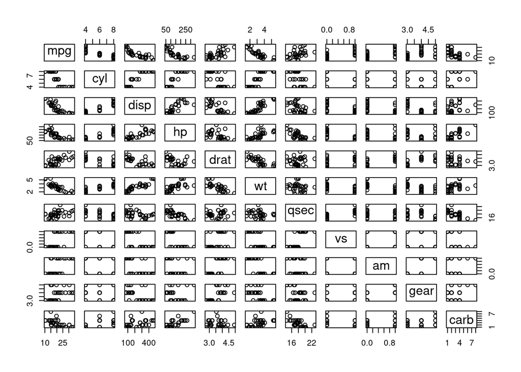

```r
# `pairs` plots pairs of variables we ask for in scatter plots.
pairs(mpg ~ ., data = mtcars)
```

Since we suspect a negative linear dependence between `mpg` and `wt` (fuel consumption and vehicle weight), we plot this one scatterplot separately:

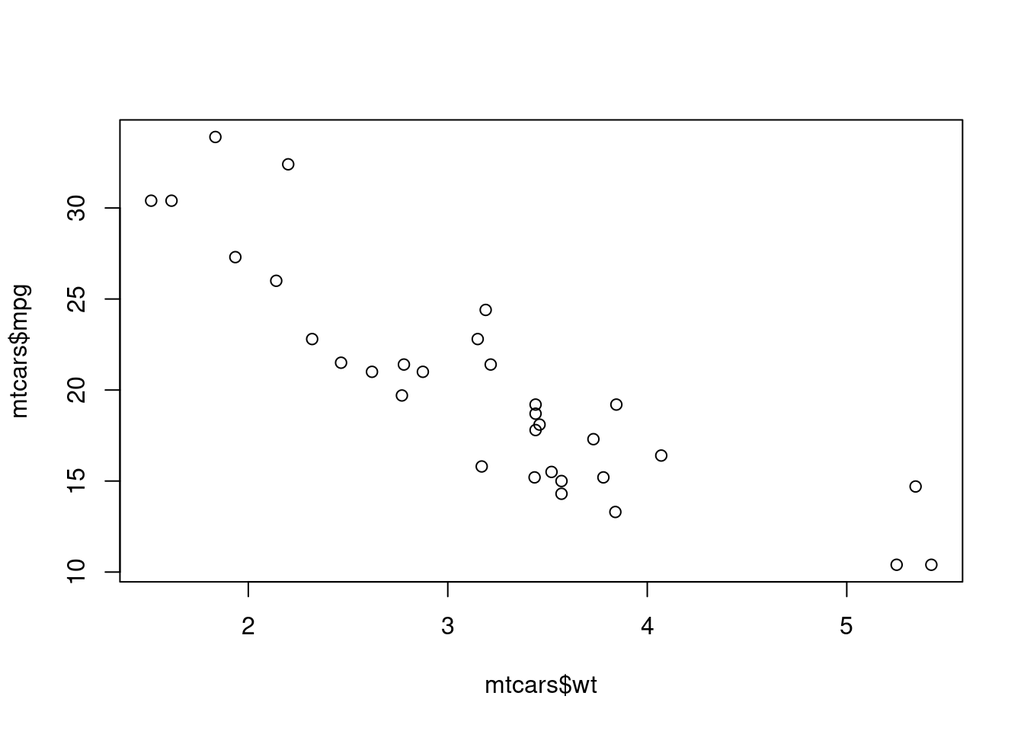

```r
plot(mtcars$wt, mtcars$mpg)
```

From this plot we might formulate a naive hypothesis:

> Heavier vehicles tend to have a less `mpg` value, i.e., tend to consume more fuel per mile.

To verify this assumption, we compute a linear regression model for those two variables:

```r
lrm <- lm(mpg ~ wt, data = mtcars)
summary(lrm)
```

```
##
## Call:
## lm(formula = mpg ~ wt, data = mtcars)
##
## Residuals:
##     Min      1Q  Median      3Q     Max
## -4.5432 -2.3647 -0.1252  1.4096  6.8727
##
## Coefficients:
##             Estimate Std. Error t value Pr(>|t|)
## (Intercept)  37.2851     1.8776  19.858  < 2e-16 ***
## wt           -5.3445     0.5591  -9.559 1.29e-10 ***
## ---
## Signif. codes:  0 '***' 0.001 '**' 0.01 '*' 0.05 '.' 0.1 ' ' 1
##
## Residual standard error: 3.046 on 30 degrees of freedom
## Multiple R-squared:  0.7528, Adjusted R-squared:  0.7446
## F-statistic: 91.38 on 1 and 30 DF,  p-value: 1.294e-10
```

By the values shown above, the resulting model is:

$$mpg=37.2851-5.3445 wt.$$

An intuitive explanation of the above formula is as follows: For every additional 1000 lbs of weight for a particular car, we get a change in miles per gallon of -5.3445 miles / (US) gallon. Also, for the (fictional) case of cars of 0 weight we should expect a mean consumption of 37.2851 miles / (US) gallon.

The model looks like the following:

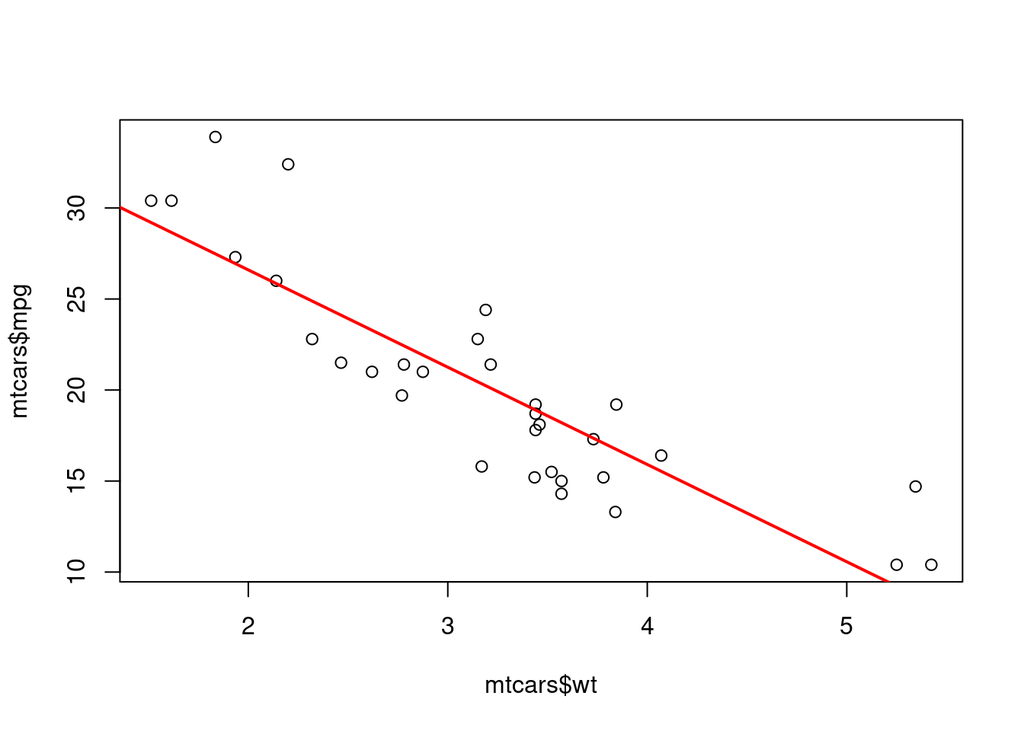

```r
plot(mtcars$wt, mtcars$mpg)
abline(lrm, col = 'red', lwd = 2)
```

## Evaluating a Linear Regression Model

We have raw inspection as a first intuitive way to verify fitness of a model, but we should also use common testing measures ($p$ values, adjusted $R^2$) but also we should use some auxiliary plots that help us make sense of how good our model is.

The first one is the Fitted vs Residuals plot:

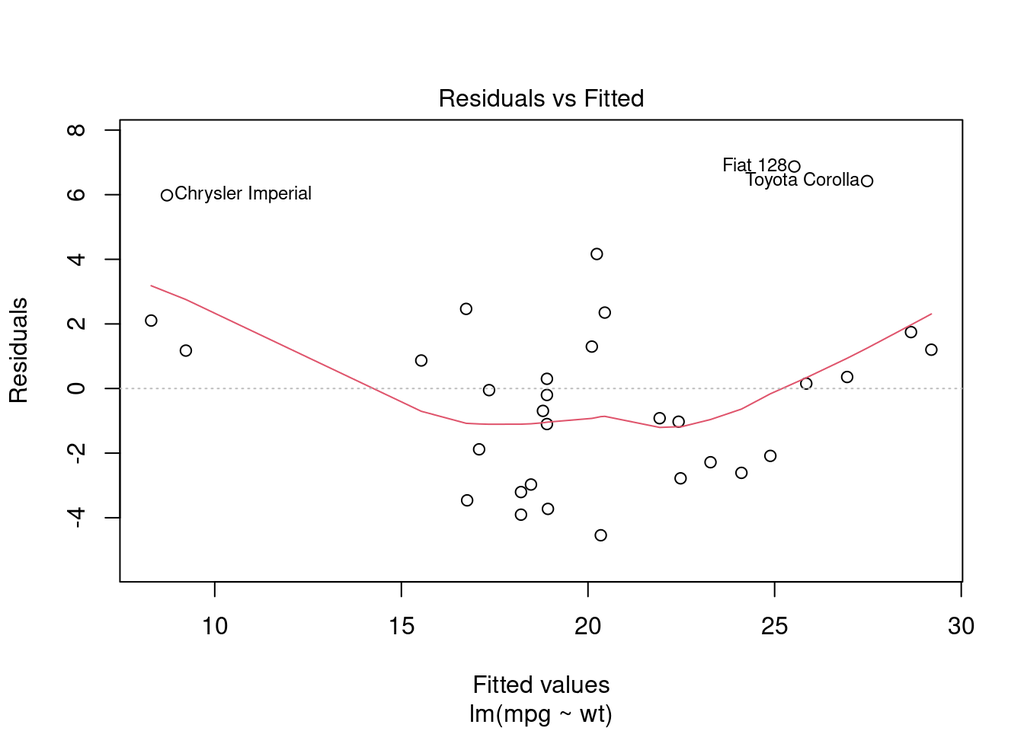

```r
plot(lrm, which = 1)
```

Ideally, we want this plot to look entirely random with the red line being close to the $residual=0$ line (dotted, in the middle of the plot). The situation above is good enough for our case and $n=32$ observations.

Next, we also have the so-called Q-Q plots:

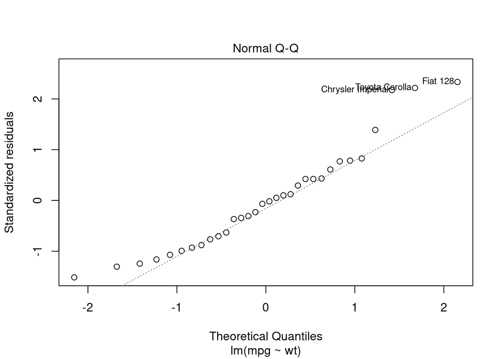

```r
plot(lrm, which = 2)
```

This plots shows where the residuals (after standardisation) stand, compared to the theoretical expectation under the assumption that they are normally distributed. So, the closer the points to the diagonal (in general), the more probable it is that residuals are indeed normally distributed, as we have assumed (otherwise the model makes no sense).

> In linear regression, we do assume that residuals are **normally distributed** around **zero** ($\mu=0$). So, since we do not have access to this population prior to actually computing the model, we need to verify this assumption. If it fails, this means that the entire model is garbage.

Next, we have a scale-location plot:

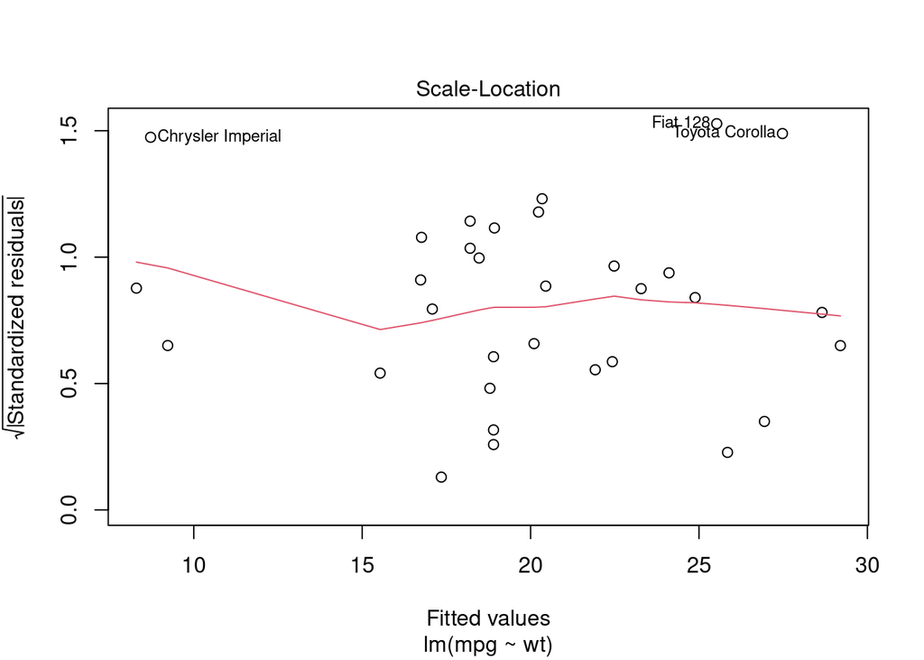

```r
plot(lrm, which = 3)
```

A scale-location plot informs us about whether (or not) there are some places (locations) in our dataset where residuals are much larger or smaller compared to other areas (scale). Ideally, this plot should look like randomly scattered points and the fitting line should, more or less, be a straight line (or close to that).

In this, as well as the previous plots, we mostly focus on $y$ axis distribution, since what happens on the $x$ axis depends mostly on the data at hand and our model’s prediction.

Next, we have Residual vs Leverage plots:

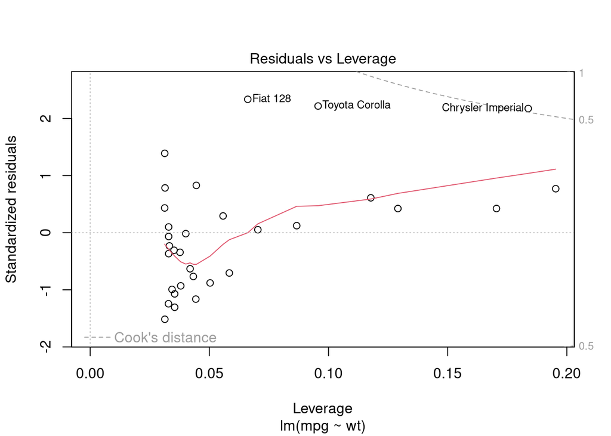

```r
plot(lrm, which = 5)
```

This plot corresponds to how much data points that affect the model more (have more leverage) do also contribute to errors. In this case we see that most points are around a $0.03-0.04$ of leverage, which makes sense (they affect at around $100/32=3.125\%$ each) besides a few that have a stronger leverage on the model but, in turn, contribute less to residuals (have residual values closer to zero). So, excluding the three outliers we have spotted, these results are more or less, good enough.

# Notes on Linear Regression

## Why we do not use SE?

If we use the formula:

$$SE=\sum_{i=1}^n\varepsilon_i$$

for quantifying errors, we might end up with a situation like the following:

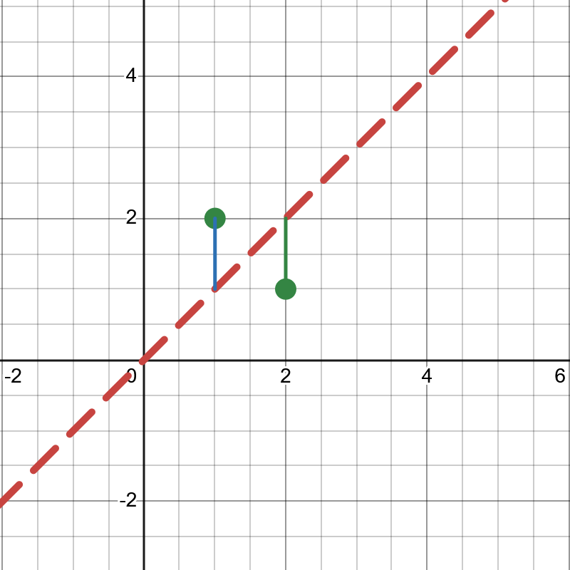

An erroneous way to quantify error in Linear Regression.

On the contrary, this is not the case with $SSE$.

## How optimisation works?

We consider the quantity:

$$SSE=\sum_{i=1}^n\varepsilon_i^2=\sum_{i=1}^n(\hat{y}_i-y_i)^2.$$
If we substitute $\hat{y}_i=\beta_0+\beta_1x_i$ we get:

$$SSE=\sum_{i=1}^n(\beta_0+\beta_1x_i-y_i)^2.$$
Since $(x_i,y_i)$ are the observations in our sample, those are know, so in pracice $SSE$ is just a function of $\beta_0$ and $\beta_1$, i.e.:

$$SSE=SSE(\beta_0,\beta_1).$$
Of this bivariate function we seek the minimum, which is given at the point shown in the slides.

## Linear Regression Party Tricks

Above, we found a nice regression relationship relating vehicle weight with miles per gallon of fuel consumed:

$$\frac{miles}{gallon}=37.2851-5.3445wt.$$

So, if we want to measure consumption, i.e., $c=\frac{gallons}{mile}$, we can just invert the above formula, i.e.:

$$c=\frac{gallons}{mile}=\frac{1}{37.2851-5.3445wt}.$$

Observe how this is a clearly non-linear relationship, stemming just from a linear one, so we can re-frame non-linear problems into linear ones, study the linear variant and then bring our newly acquired knowledge back to the non-linear problem. In this particular case, this curve looks like:

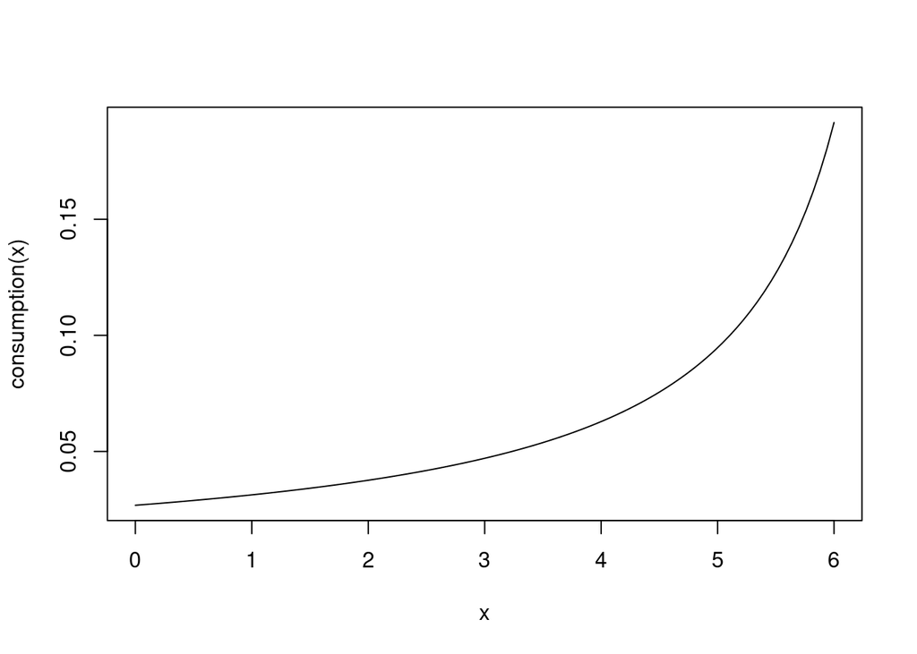

```r
consumption <- function(wt) {1 / (37.2851 - 5.3445 * wt)}
curve(consumption, xlim = c(0, 6))
```

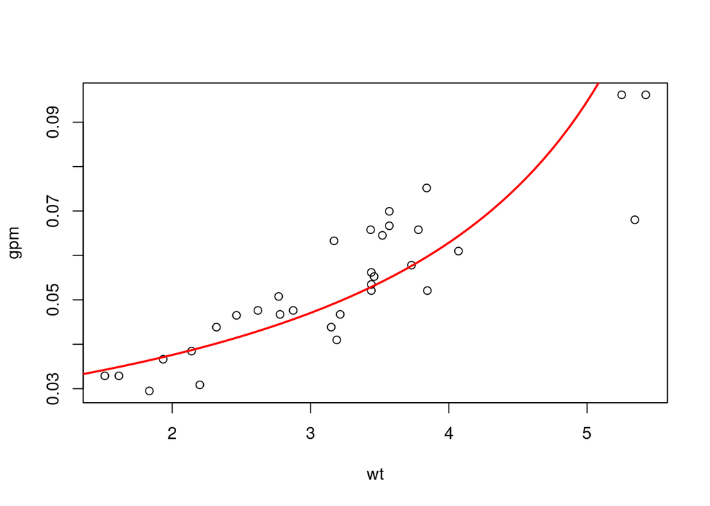

```r
wt <- mtcars$wt
gpm <- 1 / mtcars$mpg
plot(wt, gpm)
curve(consumption, xlim = c(0, 6), add = TRUE, col = 'red', lwd = 2)
```